# Individual Assignment 3: Exploratory Data Analysis and Visualization

Atharv Prashant Tungatkar

2025-10-26

Reading libraries and datasets

```r
library(ggplot2)
library(dplyr)
data<-read.csv("C:/Users/athar/OneDrive/Desktop/MBA Business Analytics/Visual Analytics/Files/marketing_campaign.csv")
```

Displaying data

```r
head(data,5)
```

```
##     ID Year_Birth  Education Marital_Status Income Kidhome Teenhome Dt_Customer
## 1 5524       1957 Graduation         Single  58138       0        0    9/4/2012
## 2 2174       1954 Graduation         Single  46344       1        1    3/8/2014
## 3 4141       1965 Graduation       Together  71613       0        0   8/21/2013
## 4 6182       1984 Graduation       Together  26646       1        0   2/10/2014
## 5 5324       1981        PhD        Married  58293       1        0   1/19/2014
##   Recency MntWines MntFruits MntMeatProducts MntFishProducts MntSweetProducts
## 1      58      635        88             546             172               88
## 2      38       11         1               6               2                1
## 3      26      426        49             127             111               21
## 4      26       11         4              20              10                3
## 5      94      173        43             118              46               27
##   MntGoldProds NumDealsPurchases NumWebPurchases NumCatalogPurchases
## 1           88                 3               8                  10
## 2            6                 2               1                   1
## 3           42                 1               8                   2
## 4            5                 2               2                   0
## 5           15                 5               5                   3
##   NumStorePurchases NumWebVisitsMonth AcceptedCmp3 AcceptedCmp4 AcceptedCmp5
## 1                 4                 7            0            0            0
## 2                 2                 5            0            0            0
## 3                10                 4            0            0            0
## 4                 4                 6            0            0            0
## 5                 6                 5            0            0            0
##   AcceptedCmp1 AcceptedCmp2 Complain Response
## 1            0            0        0        1
## 2            0            0        0        0
## 3            0            0        0        0
## 4            0            0        0        0
## 5            0            0        0        0
```

```r
str(data)
```

```
## 'data.frame':    2216 obs. of  27 variables:
##  $ ID                 : int  5524 2174 4141 6182 5324 7446 965 6177 4855 5899 ...
##  $ Year_Birth         : int  1957 1954 1965 1984 1981 1967 1971 1985 1974 1950 ...
##  $ Education          : chr  "Graduation" "Graduation" "Graduation" "Graduation" ...
##  $ Marital_Status     : chr  "Single" "Single" "Together" "Together" ...
##  $ Income             : int  58138 46344 71613 26646 58293 62513 55635 33454 30351 5648 ...
##  $ Kidhome            : int  0 1 0 1 1 0 0 1 1 1 ...
##  $ Teenhome           : int  0 1 0 0 0 1 1 0 0 1 ...
##  $ Dt_Customer        : chr  "9/4/2012" "3/8/2014" "8/21/2013" "2/10/2014" ...
##  $ Recency            : int  58 38 26 26 94 16 34 32 19 68 ...
##  $ MntWines           : int  635 11 426 11 173 520 235 76 14 28 ...
##  $ MntFruits          : int  88 1 49 4 43 42 65 10 0 0 ...
##  $ MntMeatProducts    : int  546 6 127 20 118 98 164 56 24 6 ...
##  $ MntFishProducts    : int  172 2 111 10 46 0 50 3 3 1 ...
##  $ MntSweetProducts   : int  88 1 21 3 27 42 49 1 3 1 ...
##  $ MntGoldProds       : int  88 6 42 5 15 14 27 23 2 13 ...
##  $ NumDealsPurchases  : int  3 2 1 2 5 2 4 2 1 1 ...
##  $ NumWebPurchases    : int  8 1 8 2 5 6 7 4 3 1 ...
##  $ NumCatalogPurchases: int  10 1 2 0 3 4 3 0 0 0 ...
##  $ NumStorePurchases  : int  4 2 10 4 6 10 7 4 2 0 ...
##  $ NumWebVisitsMonth  : int  7 5 4 6 5 6 6 8 9 20 ...
##  $ AcceptedCmp3       : int  0 0 0 0 0 0 0 0 0 1 ...
##  $ AcceptedCmp4       : int  0 0 0 0 0 0 0 0 0 0 ...
##  $ AcceptedCmp5       : int  0 0 0 0 0 0 0 0 0 0 ...
##  $ AcceptedCmp1       : int  0 0 0 0 0 0 0 0 0 0 ...
##  $ AcceptedCmp2       : int  0 0 0 0 0 0 0 0 0 0 ...
##  $ Complain           : int  0 0 0 0 0 0 0 0 0 0 ...
##  $ Response           : int  1 0 0 0 0 0 0 0 1 0 ...
```

# Univarite Non Graphical

## Categorical variable

Education

```r
tb<-table(data$Education)
tb
```

```
##
##   2n Cycle      Basic Graduation     Master        PhD
##        200         54       1116        365        481
```

The analysis uncover that majority of the customers have completed Graduation.

## Quantitatrive Variable

Recency

```r
library(psych)
describe(data$Recency)
```

```
##    vars    n  mean    sd median trimmed   mad min max range skew kurtosis   se
## X1    1 2216 49.01 28.95     49   48.99 37.06   0  99    99    0     -1.2 0.61
```

The basic analysis suggest that Recency is averaged around 49 and has a evenly shaped bell curve as skewness is zero. The data is also evenly spread as there are less outlier because kurtosis is less than 0.

# Univariate Graphical

## Categorical Variable

I will be using the number of teen homes as a categorical variable to plot a bar graph.

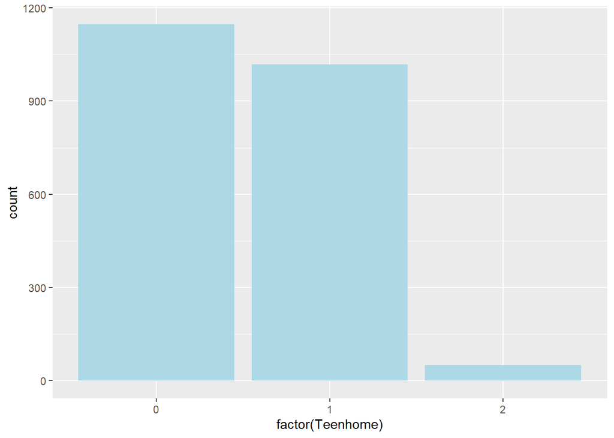

```r
library(ggplot2)
ggplot(data,aes(x=factor(Teenhome)))+geom_bar(fill="lightblue")
```

From the graph it is evident that majority of the customers don’t have a teen kid in their household.

## Quantitative Variable

I will be plotting the pl which is a smoothed version of histogram on the income variable to understand the distribution of inclome

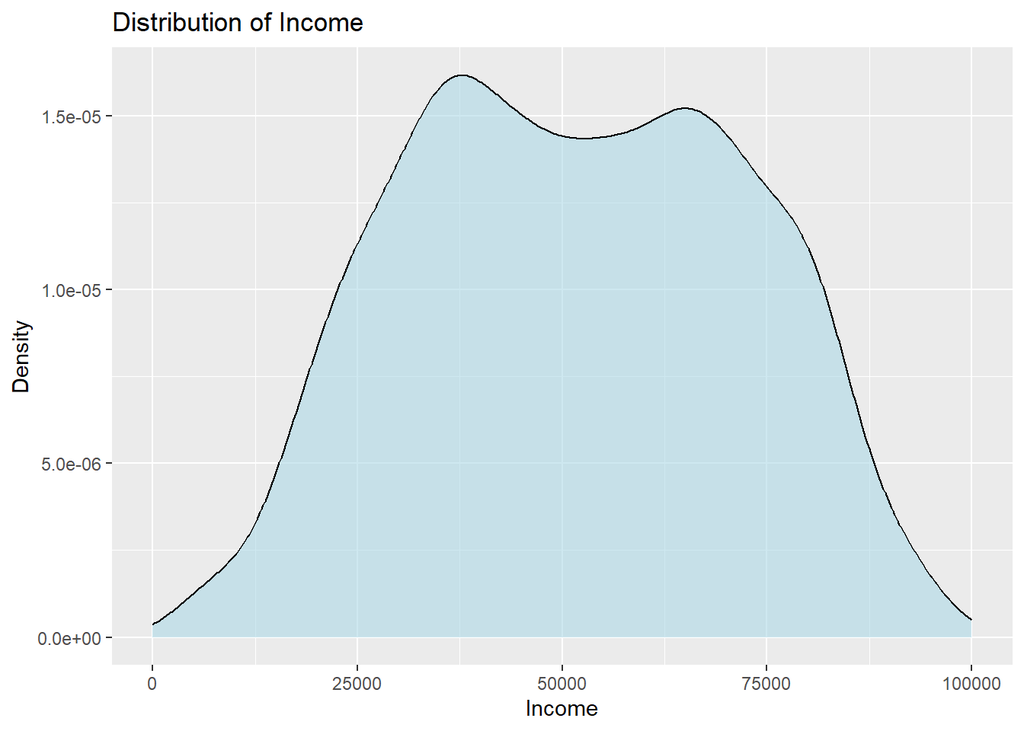

```r
ggplot(data,aes(x=Income)) +
  geom_density(fill="lightblue",alpha=0.6) +
  labs(title = "Distribution of Income",x="Income",y="Density") +
  xlim(0, 100000)
```

The graph shows that the distribution of income is bimodal with an average income of 50000.

# Multivariate Non Graphical

## Categorical Variables

Education and marital status are interesting variables to plot a cross table/

```r
ctable<-table(data$Education,data$Marital_Status)
ctable
```

```
##
##              Absurd Alone Divorced Married Single Together Widow YOLO
##   2n Cycle        0     0       23      80     36       56     5    0
##   Basic           0     0        1      20     18       14     1    0
##   Graduation      1     1      119     429    246      285    35    0
##   Master          1     1       37     138     75      102    11    0
##   PhD             0     1       52     190     96      116    24    2
```

Highest number of customers are from the graduate married category.The pattern shows that majority of customer chunk are from the education section of graduation and above with married and together being the highest contributors across those categories.

## Quantitative Variables

Lets get a correlation matrix for all the categorical variables.

```r
num_variables=data[c('Kidhome','Teenhome','Recency','MntWines','MntMeatProducts','MntFishProducts','MntSweetProducts','MntGoldProds','NumDealsPurchases','NumWebPurchases','NumWebVisitsMonth')]
cor_matrix <- cor(num_variables, use = "complete.obs", method = "pearson")
cor_matrix
```

```
##                       Kidhome     Teenhome       Recency     MntWines
## Kidhome            1.00000000 -0.039869095  0.0114921489 -0.497335858
## Teenhome          -0.03986909  1.000000000  0.0138378832  0.003746663
## Recency            0.01149215  0.013837883  1.0000000000  0.015721019
## MntWines          -0.49733586  0.003746663  0.0157210194  1.000000000
## MntMeatProducts   -0.43926053 -0.261122385  0.0225176351  0.568860003
## MntFishProducts   -0.38888422 -0.205241867  0.0005509232  0.397721050
## MntSweetProducts  -0.37802613 -0.163055777  0.0251097703  0.390325802
## MntGoldProds      -0.35502942 -0.019887234  0.0176626377  0.392730993
## NumDealsPurchases  0.21691305  0.386246304  0.0021154508  0.008885929
## NumWebPurchases   -0.37197655  0.162077185 -0.0056408538  0.553785939
## NumWebVisitsMonth  0.44747694  0.131240022 -0.0185636434 -0.321977901
##                   MntMeatProducts MntFishProducts MntSweetProducts MntGoldProds
## Kidhome               -0.43926053   -0.3888842203      -0.37802613  -0.35502942
## Teenhome              -0.26112239   -0.2052418665      -0.16305578  -0.01988723
## Recency                0.02251764    0.0005509232       0.02510977   0.01766264
## MntWines               0.56886000    0.3977210502       0.39032580   0.39273099
## MntMeatProducts        1.00000000    0.5735740153       0.53513611   0.35944628
## MntFishProducts        0.57357402    1.0000000000       0.58386696   0.42714204
## MntSweetProducts       0.53513611    0.5838669550       1.00000000   0.35744975
## MntGoldProds           0.35944628    0.4271420401       0.35744975   1.00000000
## NumDealsPurchases     -0.12130771   -0.1432410856      -0.12143193   0.05190483
## NumWebPurchases        0.30709037    0.2996875104       0.33393722   0.40706567
## NumWebVisitsMonth     -0.53948442   -0.4464232918      -0.42237080  -0.24769056
##                   NumDealsPurchases NumWebPurchases NumWebVisitsMonth
## Kidhome                 0.216913048    -0.371976549        0.44747694
## Teenhome                0.386246304     0.162077185        0.13124002
## Recency                 0.002115451    -0.005640854       -0.01856364
## MntWines                0.008885929     0.553785939       -0.32197790
## MntMeatProducts        -0.121307714     0.307090366       -0.53948442
## MntFishProducts        -0.143241086     0.299687510       -0.44642329
## MntSweetProducts       -0.121431928     0.333937217       -0.42237080
## MntGoldProds            0.051904829     0.407065666       -0.24769056
## NumDealsPurchases       1.000000000     0.241440318        0.34604838
## NumWebPurchases         0.241440318     1.000000000       -0.05122626
## NumWebVisitsMonth       0.346048380    -0.051226263        1.00000000
```

The analysis gives a glimpse of how the variables are related to each other. It is observed that the quantitative variables of Mnt purchased have the highet correlation among which MntFishProducts and MntSweetProducts have the highest correlation suggesting that customers who buy more fish tend to but more sweets.

# Multivariate Graphical

## Categorical Variables

We examine whether the Kidhome and education has any relation/pattern

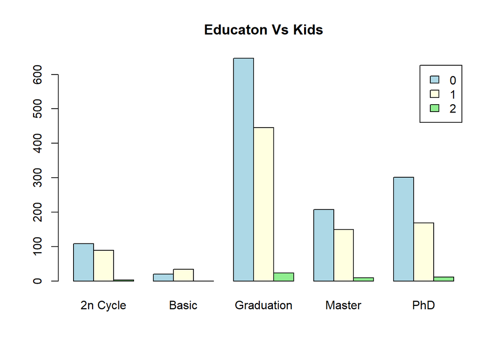

```r
t1<-table(data$Kidhome,data$Education)
barplot(t1,main="Educaton Vs Kids",legend=rownames(t1),beside=TRUE,col=c("lightblue","lightyellow","lightgreen"))
```

The pattern is same among all the categories except for Basic education where tha customers with one kid are greater than other two categories.

## Quantitative Variables

Now as the correlation analysis indicated that the sweets and fish purchases are correlated lets examine it with respect to teens home.

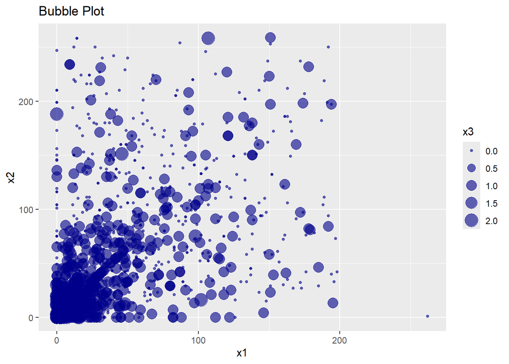

```r
ggplot(data, aes(x = MntSweetProducts, y = MntFishProducts, size = Teenhome)) +
  geom_point(alpha = 0.6, color = "darkblue") +
  labs(title = "Bubble Plot", x = "x1", y = "x2", size = "x3")
```

There is a positive correlation between Sweet and Fish purchases but the teens home have a random pattern not showing any relationship with the purchases.